# Superliga - Modelo Estadístico

Martin Alalu

9/22/2019

```r
library(tidyverse)
library(janitor)
library(ggpubr)

futbol <- read.csv("https://raw.githubusercontent.com/martoalalu/superliga-modelo/master/data/datos_2015.csv", encoding = 'UTF-8', sep=";")
futbol <- clean_names(futbol)
```

## Análisis Exploratorio

El dataframe tiene 49 variables y 30 observaciones, correspondientes a los equipos que jugaron la Superliga de fútbol durante el año 2015. De los datos se puede observar que el campeón al cabo de 30 fechas obtuvo 64 puntos, mientras que el último 14. La valoración máxima de un plantel fue de 43.4M de euros mientras que la mínima de 3.38M. El equipo que más invirtió lo hizo por un monto de 11.2M, y el que menos invirtó en realidad vendió más de lo que compró al inicio de la temporada, por un valor total de 2.9M. En términos relativos hubo un equipo que multiplicó por 1.08 la inversión realizada para el campeonato anterior mientras que hubo un equipo cuya inversión retrocedió UN 22% para esta temporada.

Durante esta temporada 7 equipos participaron de la Copa Sudamericana, mientras que 6 para la Libertadores y 2 equipos jugaron ambas competiciones continentales. Un total de 10 equipos ascendieron de la B Nacional para jugar la temporada 2015.

```r
futbol
```

| club | pts_2012_13 | pts_2013_14 | pts_2014 | inversion_abs | inversion_relativa | valor | libertadores | sudamericana | ascenso | pos | pts | pj | pg | pe | pp | gf | gc | dif | pos_fecha_1 | pos_fecha_2 | pos_fecha_3 | pos_fecha_4 | pos_fecha_5 | pos_fecha_6 | pos_fecha_7 | pos_fecha_8 | pos_fecha_9 | pos_fecha_10 | pos_fecha_11 | … |
| --- | --- | --- | --- | --- | --- | --- | --- | --- | --- | --- | --- | --- | --- | --- | --- | --- | --- | --- | --- | --- | --- | --- | --- | --- | --- | --- | --- | --- | --- | --- |
| Quilmes | 50 | 45 | 12 | 6.33 | 0.650965567 | 13.23 | 0 | 0 | 0 | 11 | 45 | 30 | 13 | 6 | 11 | 38 | 37 | 1 | 19 | 18 | 24 | 23 | 19 | 20 | 22 | 20 | 22 | 23 | 21 | … |
| Olimpo | 0 | 50 | 19 | 2.25 | 0.254892250 | 10.00 | 0 | 0 | 0 | 18 | 36 | 30 | 8 | 12 | 10 | 23 | 26 | -3 | 25 | 25 | 29 | 29 | 29 | 25 | 26 | 27 | 28 | 30 | 28 | … |
| Banfield | 0 | 0 | 20 | 7.55 | 0.590507433 | 16.93 | 0 | 0 | 0 | 8 | 50 | 30 | 14 | 8 | 8 | 38 | 32 | 6 | 19 | 12 | 12 | 18 | 13 | 9 | 5 | 6 | 7 | 9 | 10 | … |
| Godoy Cruz | 0 | 0 | 20 | 3.40 | 0.301022445 | 13.08 | 0 | 0 | 0 | 22 | 32 | 30 | 8 | 8 | 14 | 32 | 40 | -8 | 14 | 18 | 14 | 8 | 16 | 19 | 18 | 21 | 23 | 24 | 22 | … |
| Rosario Central | 0 | 54 | 21 | 10.83 | 1.088255815 | 16.33 | 0 | 0 | 0 | 3 | 59 | 30 | 16 | 11 | 3 | 47 | 26 | 21 | 8 | 4 | 3 | 1 | 1 | 1 | 3 | 4 | 4 | 4 | 5 | … |
| Defensa y Justicia | 49 | 56 | 21 | 1.27 | 0.203411970 | 6.90 | 0 | 0 | 0 | 21 | 32 | 30 | 8 | 8 | 14 | 27 | 31 | -4 | 8 | 14 | 18 | 15 | 18 | 18 | 17 | 19 | 18 | 21 | 24 | … |
| Gimnasia y Esgrima | 0 | 57 | 24 | 2.25 | 0.245660411 | 10.33 | 0 | 0 | 0 | 12 | 44 | 30 | 12 | 8 | 10 | 41 | 38 | 3 | 19 | 20 | 27 | 25 | 20 | 24 | 25 | 25 | 19 | 18 | 17 | … |
| Atlético de Rafaela | 43 | 49 | 25 | -2.15 | -0.223609643 | 8.58 | 0 | 0 | 0 | 29 | 23 | 30 | 4 | 11 | 15 | 29 | 51 | -22 | 27 | 30 | 30 | 30 | 30 | 30 | 30 | 28 | 29 | 29 | 26 | … |
| Estudiantes | 59 | 49 | 25 | 6.35 | 0.378535696 | 20.15 | 1 | 0 | 0 | 7 | 51 | 30 | 14 | 9 | 7 | 34 | 28 | 6 | 8 | 4 | 2 | 4 | 5 | 11 | 14 | 15 | 16 | 20 | 18 | … |
| Aldosivi | 74 | 56 | 25 | 0.18 | 0.027110094 | 6.73 | 0 | 0 | 1 | 15 | 40 | 30 | 11 | 7 | 12 | 37 | 40 | -3 | 27 | 29 | 27 | 25 | 21 | 21 | 21 | 17 | 20 | 11 | 8 | … |

[output cut: 20 more lines]

Para empezar vemos cuál es la correlación entre las principales variables. Sabemos que correlación no es causalidad pero nos ayudará a ir guiando la exploración.

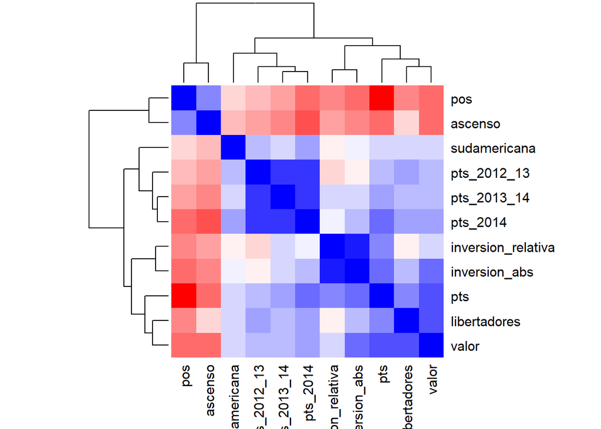

```r
cor_matrix <- cor(select(futbol, pts_2012_13,pts_2013_14,pts_2014, inversion_abs, inversion_relativa,valor,pos, pts,sudamericana, ascenso,libertadores), method = c("pearson", "kendall", "spearman"))

col<- colorRampPalette(c("red", "white", "blue"))(20)
heatmap(x = cor_matrix, col = col, symm = TRUE)
```

Cómo era esperable hay una fuerte correlación entre los puntos obtenidos sucesivamente en los últimos 3 torneos. Se destaca la correlación entre las variables valor y puntos obtenidos en el presente torneo (0.61), e inversamente entre los puntos y el hecho de haber ascendido (o sea que haber ascendido impacta negativamente en la cantidad de puntos obtenidos al final del torneo), y por último entre valor e inversión absoluta (0.57); es decir que los equipos de mayor valor de mercado y quienes más invirtieron en términos absolutos solieron tener más puntos, y por ende estar mejor posicionados. Un poco más rezagada se encuentra la correlación entre puntos e inversión relativa (es decir medida en variación respecto al año anterior), con 0.43.

```r
modelo_pts_valor <- lm(pts ~ valor, data = futbol)
modelo_pts_invabs <- lm(pts ~ inversion_abs, data = futbol)
modelo_pts_invrel <- lm(pts ~ inversion_relativa, data = futbol)

modelo_pts_valor
```

```
##
## Call:
## lm(formula = pts ~ valor, data = futbol)
##
## Coefficients:
## (Intercept)        valor
##     29.6578       0.7111
```

```r
modelo_pts_invabs
```

```
##
## Call:
## lm(formula = pts ~ inversion_abs, data = futbol)
##
## Coefficients:
##   (Intercept)  inversion_abs
##        36.142          1.744
```

```r
modelo_pts_invrel
```

```
##
## Call:
## lm(formula = pts ~ inversion_relativa, data = futbol)
##
## Coefficients:
##        (Intercept)  inversion_relativa
##              36.83               20.35
```

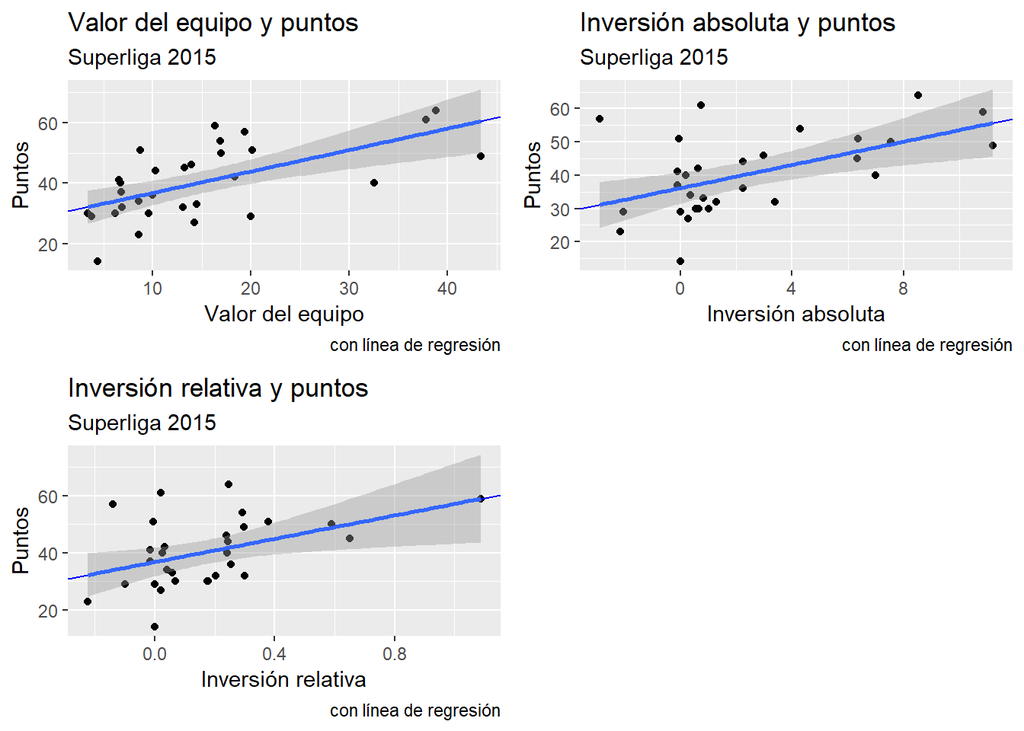

```r
ggpubr::ggarrange(ncol=2, nrow=2,
                  ggplot(data = futbol) +
                    geom_point(aes(x = valor, y = pts)) +
                    labs(title = "Valor del equipo y puntos",
                         subtitle = "Superliga 2015",
                         y = "Puntos",
                         x= "Valor del equipo",
                         caption = "con línea de regresión") +
                    geom_abline(aes(intercept = 29.6578, slope = 0.7111), color = "blue")+
                    geom_smooth(aes(x = valor, y = pts), method = "lm"),

                  ggplot(data = futbol) +
                    geom_point(aes(x = inversion_abs, y = pts)) +
                    labs(title = "Inversión absoluta y puntos",
                         subtitle = "Superliga 2015",
                         y = "Puntos",
                         x= "Inversión absoluta",
                         caption = "con línea de regresión") +
                    geom_abline(aes(intercept = 36.142, slope = 1.744), color = "blue")+
                    geom_smooth(aes(x = inversion_abs, y = pts), method = "lm"),

                  ggplot(data = futbol) +
                    geom_point(aes(x = inversion_relativa, y = pts)) +
                    labs(title = "Inversión relativa y puntos",
                         subtitle = "Superliga 2015",
                         y = "Puntos",
                         x= "Inversión relativa",
                         caption = "con línea de regresión") +
                    geom_abline(aes(intercept = 36.83, slope = 20.35), color = "blue")+
                    geom_smooth(aes(x = inversion_relativa, y = pts), method = "lm")
)
```

```r
summary(modelo_pts_valor)
```

```
##
## Call:
## lm(formula = pts ~ valor, data = futbol)
##
## Residuals:
##      Min       1Q   Median       3Q      Max
## -18.8081  -6.8428  -0.7274   6.7124  17.7294
##
## Coefficients:
##             Estimate Std. Error t value Pr(>|t|)
## (Intercept)  29.6578     3.1246   9.492 3.01e-10 ***
## valor         0.7111     0.1713   4.152 0.000279 ***
## ---
## Signif. codes:  0 '***' 0.001 '**' 0.01 '*' 0.05 '.' 0.1 ' ' 1
##
## Residual standard error: 9.725 on 28 degrees of freedom
## Multiple R-squared:  0.3811, Adjusted R-squared:  0.359
## F-statistic: 17.24 on 1 and 28 DF,  p-value: 0.0002791
```

```r
summary(modelo_pts_invabs)
```

```
##
## Call:
## lm(formula = pts ~ inversion_abs, data = futbol)
##
## Residuals:
##     Min      1Q  Median      3Q     Max
## -22.142  -7.132  -2.467   4.501  25.915
##
## Coefficients:
##               Estimate Std. Error t value Pr(>|t|)
## (Intercept)    36.1424     2.2854  15.815 1.73e-15 ***
## inversion_abs   1.7440     0.5228   3.336  0.00241 **
## ---
## Signif. codes:  0 '***' 0.001 '**' 0.01 '*' 0.05 '.' 0.1 ' ' 1
##
## Residual standard error: 10.46 on 28 degrees of freedom
## Multiple R-squared:  0.2844, Adjusted R-squared:  0.2589
## F-statistic: 11.13 on 1 and 28 DF,  p-value: 0.002407
```

```r
summary(modelo_pts_invrel)
```

```
##
## Call:
## lm(formula = pts ~ inversion_relativa, data = futbol)
##
## Residuals:
##      Min       1Q   Median       3Q      Max
## -22.8305  -8.1469  -0.8645   4.4746  23.7623
##
## Coefficients:
##                    Estimate Std. Error t value Pr(>|t|)
## (Intercept)          36.830      2.444  15.069 5.82e-15 ***
## inversion_relativa   20.347      7.909   2.573   0.0157 *
## ---
## Signif. codes:  0 '***' 0.001 '**' 0.01 '*' 0.05 '.' 0.1 ' ' 1
##
## Residual standard error: 11.12 on 28 degrees of freedom
## Multiple R-squared:  0.1912, Adjusted R-squared:  0.1623
## F-statistic: 6.618 on 1 and 28 DF,  p-value: 0.01569
```

Estos 3 modelos son excesivamente simples, en el sentido de que sólo consideran el efecto de una sola variable independiente por separado (valor del plantel, inversión absoluta y relativa) en la dependiente (pts), sin tener en cuenta el resto (que en este caso serían parte de los errores de estimación).

El primero intenta explicar la variación de los puntos obtenidos a partir del valor del plantel, y se los resultados podemos obtenemos que el incremento de un millón de euros en el valor del plantel trae aparejado un incremento de 0.7 puntos al final del torneo. Este hallazgo es estadísticamente significativo y permite explicar el 35% de la varianza de los puntos.

El segundo modelo sólo considera la inversión absoluta como variable independiente, la cual explica también el 25% de la varianza de los puntos y es estadísticamente significativa. Ante el incremento de un millón de euros en la inversión respecto del año pasado se esperaría un incremento de 1.7 puntos al final de la temporada.

Por último el modelo que sólo utiliza la inversión relativa al año anterior. Ante un incremento de un 10% de la inversión respecto de la temporada anterior se esperaría un incremento de 2 puntos botenidos al final del torneo. Este hallazgo es estadísticamente significativo pero sólo explica un 16% de la varianza de puntos.

Analizamos ahora con un modelo más complejo, que tenga en cuenta todas las variables disponibles y así veremos si ganamos o no en poder explicativo.

```r
#Modelo
modelo_pts <- lm(pts ~ pts_2012_13 + pts_2013_14 + pts_2014 + inversion_abs +
                  inversion_relativa + valor + libertadores + sudamericana + ascenso,
                  data = futbol)

summary(modelo_pts)
```

```
##
## Call:
## lm(formula = pts ~ pts_2012_13 + pts_2013_14 + pts_2014 + inversion_abs +
##     inversion_relativa + valor + libertadores + sudamericana +
##     ascenso, data = futbol)
##
## Residuals:
##      Min       1Q   Median       3Q      Max
## -12.1568  -3.9097  -0.2494   3.4886  15.7965
##
## Coefficients:
##                     Estimate Std. Error t value Pr(>|t|)
## (Intercept)        15.058086   7.459359   2.019   0.0571 .
## pts_2012_13        -0.084927   0.103988  -0.817   0.4237
## pts_2013_14         0.008748   0.106711   0.082   0.9355
## pts_2014            0.575616   0.223596   2.574   0.0181 *
## inversion_abs      -2.173272   1.268791  -1.713   0.1022
## inversion_relativa 40.110542  15.874772   2.527   0.0201 *
## valor               0.834816   0.338797   2.464   0.0229 *
## libertadores        3.896544   5.391639   0.723   0.4782
## sudamericana       -1.348871   3.915157  -0.345   0.7340
## ascenso             7.400458   5.703893   1.297   0.2092
## ---
## Signif. codes:  0 '***' 0.001 '**' 0.01 '*' 0.05 '.' 0.1 ' ' 1
##
## Residual standard error: 7.973 on 20 degrees of freedom
## Multiple R-squared:  0.7028, Adjusted R-squared:  0.5691
## F-statistic: 5.256 on 9 and 20 DF,  p-value: 0.0009804
```

En primer lugar las variables independientes seleccionadas (puntos en las 3 temporadas anteriores, inversión absoluta y relativa, el valor del equipo, el hecho de haber jugado la Copa Libertadores o la Copa Sudamericana y haber ascendido) explican en 56% la variación en los puntos. Hay 3 variables independientes cuyo estimador es estadísticamente significativo en un 95%, los puntos obtenidos en la temporada anterior (2014), la inversión relativa y el valor del equipo. En el primer caso por cada punto obtenido en el torneo 2014 conlleva un incremento de 0.57 puntos en los puntos obtenidos durante el torneo 2015; duplicar la inversión relativa implica un incremento de 40 puntos (cabe destacar que sólo un equipo hizo tal incremento, Rosario Central, cuya inversión relativa fue de 1.08), o bien incrementar un 10% la inversión implica un incremento de 4 puntos; por último por cada incremento de un millón de euros en el valor del equipo implica un incremento de 0.83 puntos. Estos efectos señalados se dan manteniendo constantes el resto de las variables independientes del modelo. En este modelo participar o no de la Copa Libertadores o Copa Sudamericana, o bien haber ascendido no tiene ningún impacto estadísticamente significativo sobre los puntos obtenidos, algo que va en contra de la intuición futbolera (los equipos que juegan copas le dan prioridad a ellas por ser torneos más prestigiosos y se ven obligados a usar equipos alternativos en el torneo local y los equipos que ascienden tienen menos recursos y menos experiencia en primera, por ende corren con desventaja frente al resto).

# Diagnóstico del modelo

En primer lugar vemos cómo se distribuyen los residuos

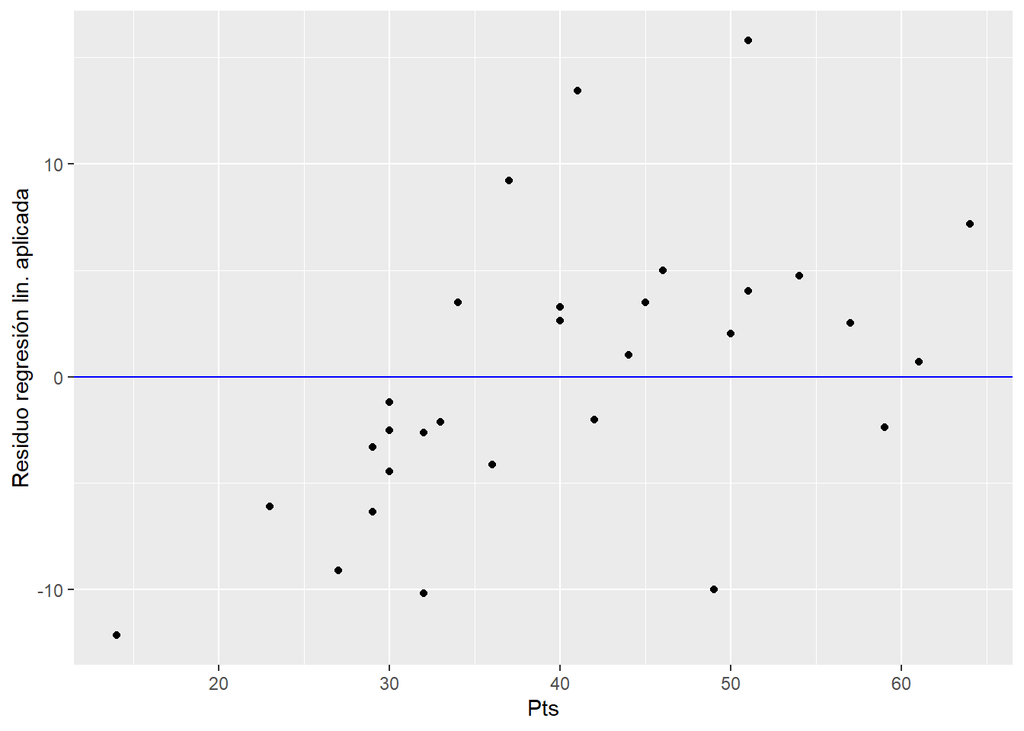

```r
residuos1 <- residuals(modelo_pts)

# Agrego la columna de con los residuos al data frame y los visualizamos

futbol <- futbol %>% mutate(residuo_ml = residuos1)

ggplot(futbol) +
    geom_point(aes(x = pts, y = residuo_ml)) +
    geom_hline(yintercept = 0, col = "blue") +
    labs(x = "Pts", y = "Residuo regresión lin. aplicada")
```

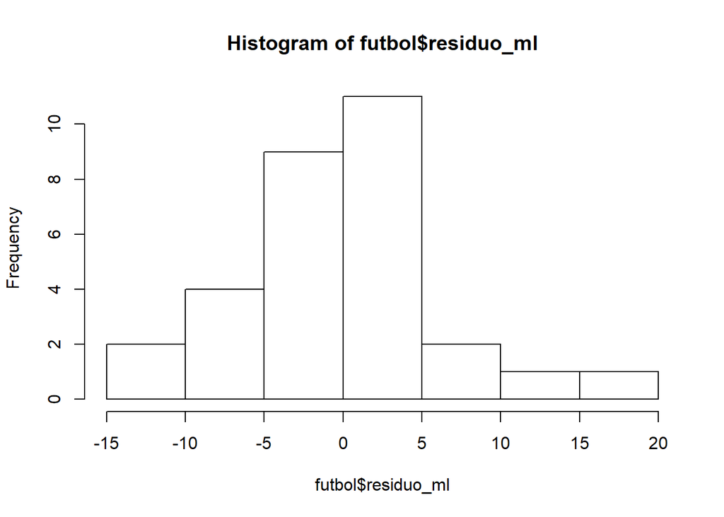

```r
hist(futbol$residuo_ml)
```

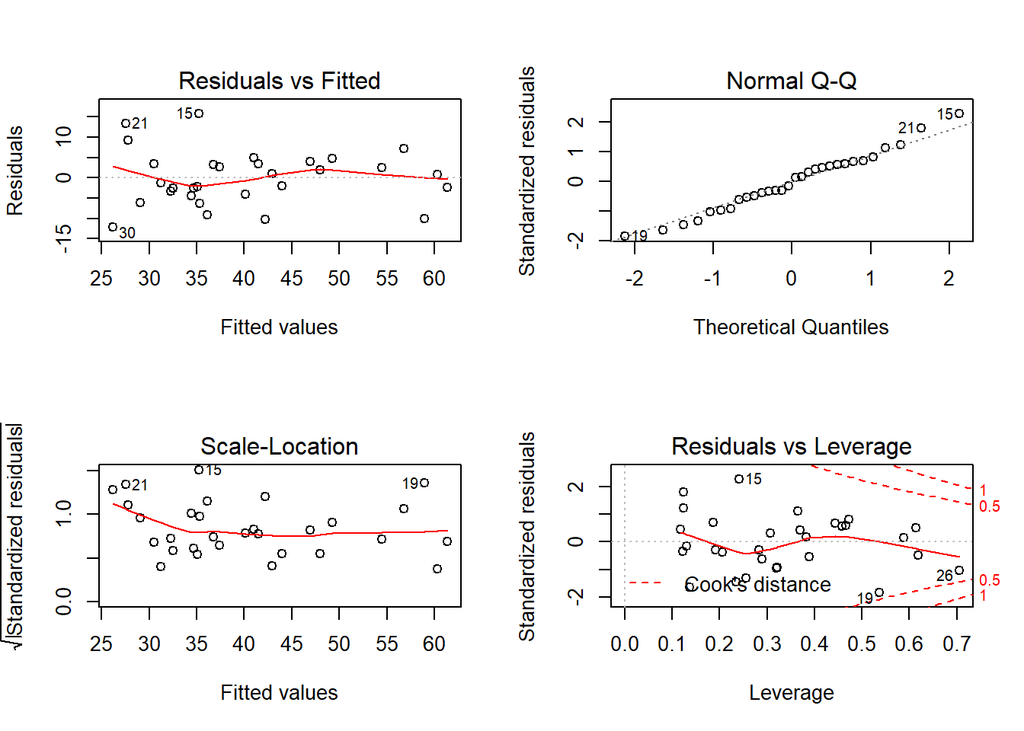

```r
par(mfrow=c(2,2)) # Change the panel layout to 2 x 2
plot(modelo_pts)
```

```r
par(mfrow=c(1,1))
```

El primer gráfico (Residuals vs Fitted) muestra si los residuos tienen patrones no lineales. En este caso es posible descartar la no-linealidad de los residuos del modelo, es decir que los mismos se pareceb distribuirse aleatoriamente, sin presentar patrón alguno. El segundo gráfico muestra que los residuos tienen una distribución normal, algo que nuevamente es positivo. El tercero muestra la distribución de los residuos a lo largo de los rangos de los predictores, de modo tal de chequear la asunción de homocedasticidad (igual varianza de los residuos en función de X). En este caso la homocedasticidad se cumple al estar los residuos distribuidos aleatoriamente, una vez más. El último gráfico permite encontrar casos que están influenciando en el modelo de sobremanera, de modo tal que alteran los resultados del mismo (empujandolo para arriba o para abajo). Nuevamente, ningún caso tiene un valor elevado en términos de la distancia de Cook, por lo que no hay casos extremos que estén influenciando en el modelo y por ende alteren los resultados.

Ahora bien, con la función step podemos ir evaluando distintos modelos sustrayendo variables y ver cuál es el que mejor poder explicativo tiene.

```r
step(modelo_pts)
```

```
## Start:  AIC=132.4
## pts ~ pts_2012_13 + pts_2013_14 + pts_2014 + inversion_abs +
##     inversion_relativa + valor + libertadores + sudamericana +
##     ascenso
##
##                      Df Sum of Sq    RSS    AIC
## - pts_2013_14         1      0.43 1271.8 130.41
## - sudamericana        1      7.55 1279.0 130.58
## - libertadores        1     33.20 1304.6 131.17
## - pts_2012_13         1     42.40 1313.8 131.38
## <none>                            1271.4 132.40
## - ascenso             1    107.01 1378.4 132.82
## - inversion_abs       1    186.51 1457.9 134.51
## - valor               1    385.98 1657.4 138.35
## - inversion_relativa  1    405.84 1677.3 138.71
## - pts_2014            1    421.30 1692.7 138.99
##
## Step:  AIC=130.41
## pts ~ pts_2012_13 + pts_2014 + inversion_abs + inversion_relativa +
##     valor + libertadores + sudamericana + ascenso
##
##                      Df Sum of Sq    RSS    AIC
## - sudamericana        1      8.26 1280.1 128.60
## - libertadores        1     32.91 1304.8 129.18
## - pts_2012_13         1     61.06 1332.9 129.82
## <none>                            1271.8 130.41
## - ascenso             1    107.47 1379.3 130.84
## - inversion_abs       1    186.18 1458.0 132.51
## - valor               1    387.90 1659.8 136.40
## - inversion_relativa  1    412.75 1684.6 136.84
## - pts_2014            1    458.42 1730.3 137.65
##
## Step:  AIC=128.6
## pts ~ pts_2012_13 + pts_2014 + inversion_abs + inversion_relativa +
##     valor + libertadores + ascenso
##
##                      Df Sum of Sq    RSS    AIC
## - libertadores        1     33.46 1313.6 127.38
## - pts_2012_13         1     57.59 1337.7 127.92
## <none>                            1280.1 128.60
```

[output cut: 15 more lines]

```
## - inversion_relativa  1    511.20 1824.8 135.24
## - pts_2014            1    533.75 1847.3 135.61
## - valor               1    806.24 2119.8 139.74
##
## Step:  AIC=126.48
## pts ~ pts_2014 + inversion_abs + inversion_relativa + valor +
##     ascenso
##
##                      Df Sum of Sq    RSS    AIC
## <none>                            1362.7 126.48
## - ascenso             1    151.63 1514.4 127.65
## - inversion_abs       1    235.60 1598.3 129.27
## - inversion_relativa  1    533.79 1896.5 134.40
## - pts_2014            1    645.87 2008.6 136.12
## - valor               1    762.31 2125.0 137.81
```

```
##
## Call:
## lm(formula = pts ~ pts_2014 + inversion_abs + inversion_relativa +
##     valor + ascenso, data = futbol)
##
## Coefficients:
##        (Intercept)            pts_2014       inversion_abs
##            13.5176              0.4665             -2.3508
## inversion_relativa               valor             ascenso
##            43.9452              0.9416              7.8035
```

```r
modelo_step <- lm(pts ~ pts_2014 + inversion_abs + inversion_relativa +
    valor + ascenso, data = futbol)

summary(modelo_step)
```

```
##
## Call:
## lm(formula = pts ~ pts_2014 + inversion_abs + inversion_relativa +
##     valor + ascenso, data = futbol)
##
## Residuals:
##     Min      1Q  Median      3Q     Max
## -12.303  -3.851  -0.657   3.961  14.887
##
## Coefficients:
##                    Estimate Std. Error t value Pr(>|t|)
## (Intercept)         13.5176     6.0767   2.224  0.03578 *
## pts_2014             0.4665     0.1383   3.373  0.00252 **
## inversion_abs       -2.3508     1.1540  -2.037  0.05282 .
## inversion_relativa  43.9452    14.3326   3.066  0.00530 **
## valor                0.9416     0.2570   3.664  0.00123 **
## ascenso              7.8035     4.7753   1.634  0.11528
## ---
## Signif. codes:  0 '***' 0.001 '**' 0.01 '*' 0.05 '.' 0.1 ' ' 1
##
## Residual standard error: 7.535 on 24 degrees of freedom
## Multiple R-squared:  0.6815, Adjusted R-squared:  0.6152
## F-statistic: 10.27 on 5 and 24 DF,  p-value: 2.345e-05
```

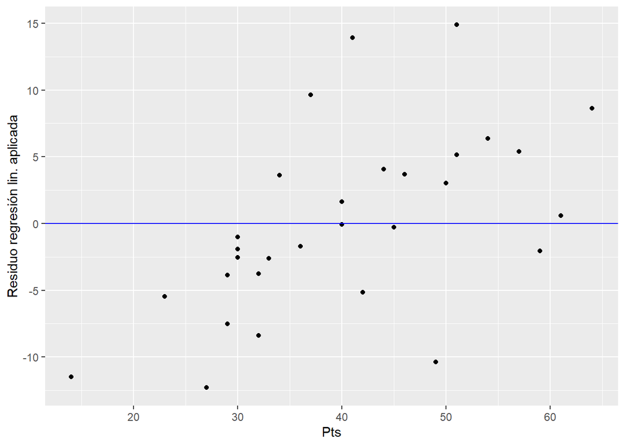

```r
residuos_step <- residuals(modelo_step)

# Agrego la columna de con los residuos al data frame y los visualizamos

futbol <- futbol %>% mutate(residuo_step = residuos_step)

ggplot(futbol) +
    geom_point(aes(x = pts, y = residuos_step)) +
    geom_hline(yintercept = 0, col = "blue") +
    labs(x = "Pts", y = "Residuo regresión lin. aplicada")
```

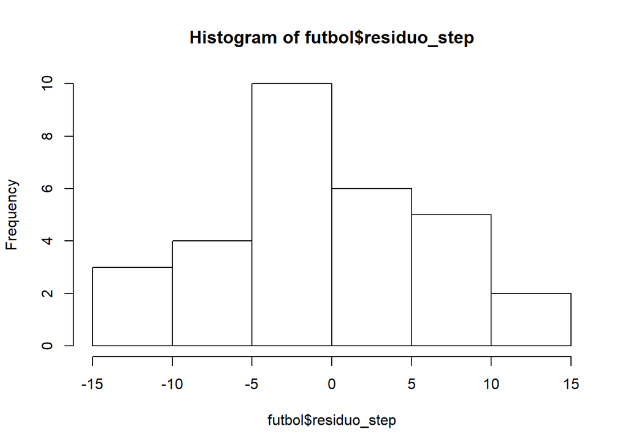

```r
hist(futbol$residuo_step)
```

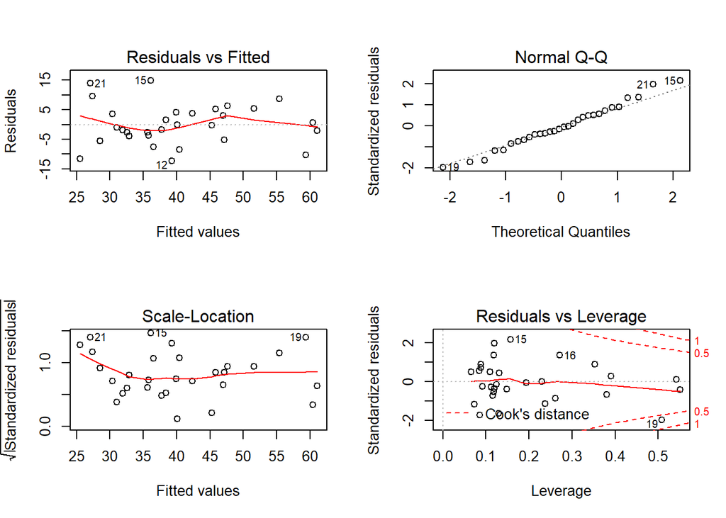

```r
par(mfrow=c(2,2)) # Change the panel layout to 2 x 2
plot(modelo_step)
```

```r
par(mfrow=c(1,1))
```

# Transformación de variables

Si bien las escalas de las variables no difieren mucho probamos ahora el mismo modelo pero con las variables en escala logaritmica para estandarizarlas.

```r
futbol <- futbol %>%
  mutate(log_pts = log(pts),
         inversion_abs_log=log(inversion_abs),
         inversion_relativa_log=log(inversion_relativa),
         valor_log=log(valor),
         ascenso_log=log(ascenso),
         pts_2014_log=log(pts_2014))

futbol$inversion_abs_log
```

```
##  [1]  1.8453002  0.8109302  2.0215476  1.2237754  2.3823201  0.2390169
##  [7]  0.8109302        NaN  1.8484548 -1.7147984       -Inf -1.2729657
## [13]  1.0885620 -0.2876821        NaN  2.1435894  1.4586150 -0.4780358
## [19]  2.4159138        NaN        NaN  1.9459101        NaN -1.0498221
## [25] -0.1863296 -0.4307829  0.0000000 -0.5978370        NaN       -Inf
```

Al revisar los nuevos valores vemos que al aplicar la escala logaritmica en la variable “inversión_absoluta” tenemos NaN y “- infinito” por lo que no podremos correr el nuevo modelo. Probamos usar otro método para estandarizarlas centrado en la media.

```r
library(robustHD)

futbol <- futbol %>%
  mutate(pts_std = standardize(pts),
         inversion_abs_std=standardize(inversion_abs),
         inversion_relativa_std=standardize(inversion_relativa),
         valor_std=standardize(valor),
         ascenso_std=standardize(ascenso),
         pts_2014_std=standardize(pts_2014))

modelo_std <- lm(pts_std ~ pts_2014_std + inversion_abs_std + inversion_relativa_std +
    valor_std + ascenso_std, data = futbol)

summary(modelo_std)
```

```
##
## Call:
## lm(formula = pts_std ~ pts_2014_std + inversion_abs_std + inversion_relativa_std +
##     valor_std + ascenso_std, data = futbol)
##
## Residuals:
##      Min       1Q   Median       3Q      Max
## -1.01291 -0.31706 -0.05409  0.32610  1.22562
##
## Coefficients:
##                          Estimate Std. Error t value Pr(>|t|)
## (Intercept)            -1.982e-16  1.133e-01   0.000  1.00000
## pts_2014_std            5.308e-01  1.574e-01   3.373  0.00252 **
## inversion_abs_std      -7.189e-01  3.529e-01  -2.037  0.05282 .
## inversion_relativa_std  9.443e-01  3.080e-01   3.066  0.00530 **
## valor_std               8.174e-01  2.231e-01   3.664  0.00123 **
## ascenso_std             3.080e-01  1.885e-01   1.634  0.11528
## ---
## Signif. codes:  0 '***' 0.001 '**' 0.01 '*' 0.05 '.' 0.1 ' ' 1
##
## Residual standard error: 0.6204 on 24 degrees of freedom
## Multiple R-squared:  0.6815, Adjusted R-squared:  0.6152
## F-statistic: 10.27 on 5 and 24 DF,  p-value: 2.345e-05
```

Mantiendo el modelo_step vamos a agregar una nueva variable que mide la eficiencia en la inversión en el torneo pasado para capturar en qué medida una buena inversión en el torneo 2014 impacta o no positivamente en la performance del torneo 2015. Es esperable que el rendimiento de un equipo no sea inmediato sino que tenga cierto lag, esta variable intenta capturar esta maduración esperable de un equipo.

```r
futbol <- futbol %>%
  mutate(valor_2014=valor-inversion_abs)

futbol <- futbol %>%
  mutate(eficiencia_2014=valor_2014 / pts_2014)

futbol$eficiencia_2014[!is.finite(futbol$eficiencia_2014)]<- 0

modelo_step_2 <- lm(pts ~ pts_2014 + inversion_abs +
                   inversion_relativa + valor + ascenso + eficiencia_2014,
                 data = futbol)

summary(modelo_step_2)
```

```
##
## Call:
## lm(formula = pts ~ pts_2014 + inversion_abs + inversion_relativa +
##     valor + ascenso + eficiencia_2014, data = futbol)
##
## Residuals:
##      Min       1Q   Median       3Q      Max
## -12.0960  -4.2788  -0.5357   3.9409  14.7023
##
## Coefficients:
##                    Estimate Std. Error t value Pr(>|t|)
## (Intercept)         12.9840     6.5692   1.976  0.06021 .
## pts_2014             0.4944     0.1814   2.726  0.01205 *
## inversion_abs       -2.4632     1.2632  -1.950  0.06347 .
## inversion_relativa  45.2411    15.5453   2.910  0.00788 **
## valor                0.9921     0.3333   2.977  0.00675 **
## ascenso              7.8963     4.8862   1.616  0.11972
## eficiencia_2014     -2.0748     8.4507  -0.246  0.80824
## ---
## Signif. codes:  0 '***' 0.001 '**' 0.01 '*' 0.05 '.' 0.1 ' ' 1
##
## Residual standard error: 7.687 on 23 degrees of freedom
## Multiple R-squared:  0.6823, Adjusted R-squared:  0.5995
## F-statistic: 8.234 on 6 and 23 DF,  p-value: 7.926e-05
```

http://www.rpubs.com/gabymill/556908

# Intervalos de confianza

Construimos los intervalos de confianza para los parámetros obtenidos en el modelo_step

```r
reg <- function(X,Y){
  boot <- sample.int(nrow(futbol),nrow(futbol),replace=T)
  boot_fit = lm(pts ~ pts_2014 + inversion_abs + inversion_relativa +
                  valor + ascenso,data=futbol[boot,])
  return(coef(boot_fit))
}

boot <- t(replicate(10000,reg(X,Y)))
head(boot)
```

```
##      (Intercept)  pts_2014 inversion_abs inversion_relativa     valor
## [1,]   14.463071 0.3735520     -2.693497           45.81814 1.0306870
## [2,]   19.445102 0.6359408     -1.253064           25.29880 0.5214799
## [3,]   16.662918 0.4415764     -2.507880           43.85518 0.9027087
## [4,]   14.478317 0.3887384     -2.849695           50.75373 1.0393630
## [5,]    6.803529 0.5850233     -1.716217           38.16449 1.1193616
## [6,]   14.472173 0.3008266     -1.852119           38.27135 1.0005829
##       ascenso
## [1,] 6.933269
## [2,] 6.836471
## [3,] 8.595136
## [4,] 6.044444
## [5,] 9.851370
## [6,] 9.199738
```

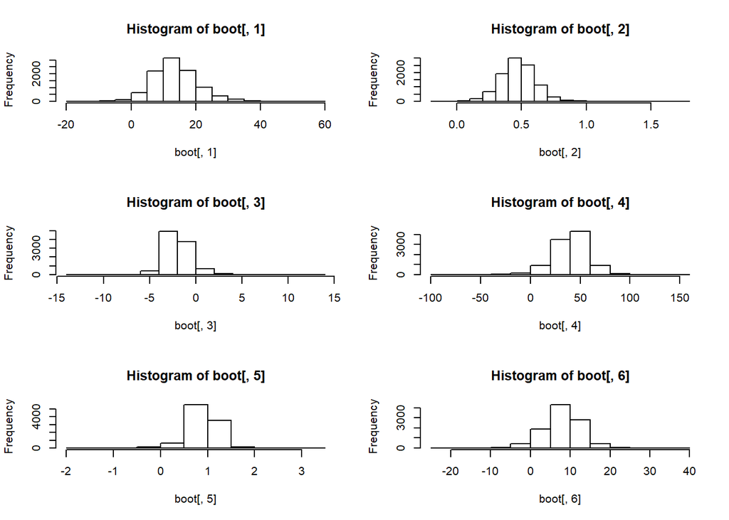

```r
par(mfrow=c(3,2))
hist(boot[,1])
hist(boot[,2])
hist(boot[,3])
hist(boot[,4])
hist(boot[,5])
hist(boot[,6])
```

```r
quantile(boot[,1],p=c(.025,.25,.5,.75,.975))
```

```
##      2.5%       25%       50%       75%     97.5%
##  1.872514  9.194253 13.106004 17.506756 29.192759
```

```r
quantile(boot[,2],p=c(.025,.25,.5,.75,.975))
```

```
##      2.5%       25%       50%       75%     97.5%
## 0.1934308 0.3848472 0.4722892 0.5582378 0.7438982
```

```r
quantile(boot[,3],p=c(.025,.25,.5,.75,.975))
```

```
##      2.5%       25%       50%       75%     97.5%
## -4.352733 -2.941781 -2.139368 -1.132739  1.515263
```

```r
quantile(boot[,4],p=c(.025,.25,.5,.75,.975))
```

```
##      2.5%       25%       50%       75%     97.5%
##  1.201656 30.252883 41.490028 51.442278 72.210906
```

```r
quantile(boot[,5],p=c(.025,.25,.5,.75,.975))
```

```
##      2.5%       25%       50%       75%     97.5%
## 0.1348448 0.7746052 0.9289176 1.0722425 1.4215708
```

```r
quantile(boot[,6],p=c(.025,.25,.5,.75,.975))
```

```
##      2.5%       25%       50%       75%     97.5%
## -1.459279  5.248869  8.221979 10.980021 16.846245
```

```r
#Si hacemos confint del modelo dan distintos valores! ¿Es porque los otros están bootsrapeados?
confint(modelo_step)
```

```
##                         2.5 %      97.5 %
## (Intercept)         0.9759153 26.05923445
## pts_2014            0.1810062  0.75189869
## inversion_abs      -4.7326344  0.03104736
## inversion_relativa 14.3641559 73.52627402
## valor               0.4112167  1.47198017
## ascenso            -2.0521436 17.65920382
```

# Test de hipótesis vía simulación

El objetivo principal es ver si el modelo elegido performa mejor que uno solo con la media, es decir si el modelo predice mejor que el ruido mismo. Vemos si los estimadores son estadísticamente significativos a partir de la técnica de bootstrapping.

```r
#Defino los 2 modelos, uno con la VD y todas las VI y otro solo con la VD

datreg_M1 <- select(futbol, pts, pts_2014, inversion_abs, inversion_relativa, valor, ascenso)
datreg_M0 <- select(futbol, pts)

# Modelos

# Mi modelo: M1
fit_M1 <- lm(pts ~ ., data = datreg_M1)
# El modelo M0 (anidado dentro de M1)
fit_M0 <- lm(pts ~ ., data = datreg_M0)

summary(fit_M0)
```

```
##
## Call:
## lm(formula = pts ~ ., data = datreg_M0)
##
## Residuals:
##      Min       1Q   Median       3Q      Max
## -26.3333  -9.8333  -0.3333   9.4167  23.6667
##
## Coefficients:
##             Estimate Std. Error t value Pr(>|t|)
## (Intercept)   40.333      2.218   18.19   <2e-16 ***
## ---
## Signif. codes:  0 '***' 0.001 '**' 0.01 '*' 0.05 '.' 0.1 ' ' 1
##
## Residual standard error: 12.15 on 29 degrees of freedom
```

```r
# Extraigo los errores
residuos_M1 <- fit_M1$residuals
residuos_M0 <- fit_M0$residuals



# Extraigo la prediccion del modelo nulo M0, la cual voy a usar para generar un data set sintético
#Esta es la predicción basandonos en la media nada mas
B0 = fit_M0$fitted.values



# Calculo el valor del test F observado

## Calculo la suma de los errores al cuadrado (desviación respecto a la media) del modelo de interés (M1, quien contiene al otro modelo) y M0 contine solo el intercept
RSS_M1 <- sum(residuos_M1 ^ 2)
RSS_M0 <- sum(residuos_M0 ^ 2)

## Calculo los grados de libertad
p_M0 <- fit_M0$rank
p_M1 <- fit_M1$rank
N = nrow(datreg_M1)

## Calculo el numerador y el denominador
numerador = (RSS_M0 - RSS_M1) / (p_M1 - p_M0)
denominador = RSS_M1 / (N - p_M1)

## Calculo F
F_obs <- numerador / denominador
F_obs
```

```
## [1] 10.27088
```

```r
reg <- function(datreg_M0, datreg_M1, B0, residuos_M1) {
  # índice para hacer el boostrap
  N <- nrow(datreg_M1)
  boot_i <- sample.int(N, N, replace = T)

  # y sintético (recuerden que R copia lo que ingresa a la func)
  residuos_2_boot <- residuos_M1[boot_i]
  datreg_M0$y <-  residuos_2_boot + B0
  datreg_M1$y <-  residuos_2_boot + B0

  # M1 con los y's sintéticos
  boot_fit_M0 =  lm(y ~ ., data = datreg_M0)
  boot_fit_M1 =  lm(y ~ ., data = datreg_M1)

  # Residuos
  boot_residuos_M0 <- boot_fit_M0$residuals
  boot_residuos_M1 <- boot_fit_M1$residuals

  # Suma residuos al cuadrado
  RSS_M0 <- sum(boot_residuos_M0 ^ 2)
  RSS_M1 <- sum(boot_residuos_M1 ^ 2)

  # F simulacion boot
  p_M0 <- boot_fit_M0$rank
  p_M1 <- boot_fit_M1$rank
  numerador = (RSS_M0 - RSS_M1) / (p_M1 - p_M0)
  denominador = RSS_M1 / (N - p_M1)
  F_boot <- numerador / denominador

  # Devuelve F_boot
  return(F_boot)
}


boot <-
  t(replicate(2000, reg(datreg_M0, datreg_M1, B0, residuos_M1)))


# Que tan probable es?
mean(F_obs < boot)
```

```
## [1] 0
```

```r
(mean(F_obs < boot)) < .05
```

```
## [1] TRUE
```

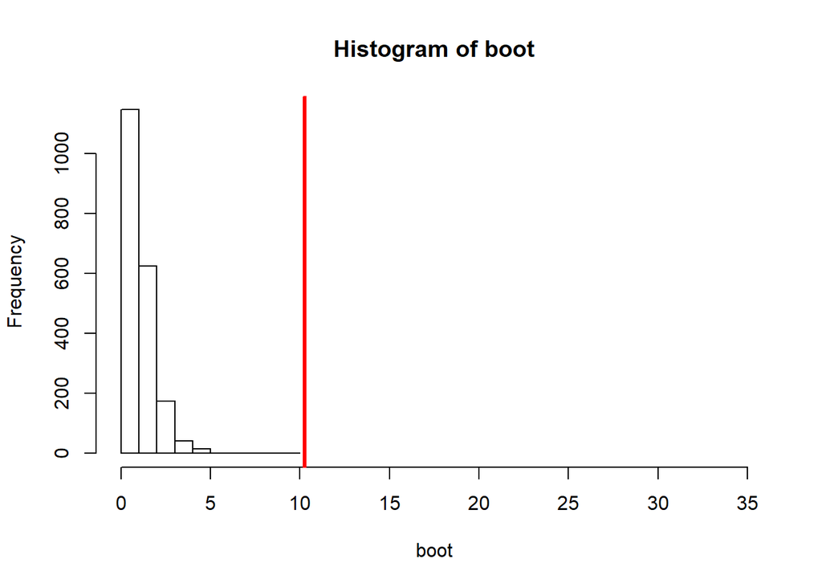

```r
hist(boot,xlim = c(0,35))
abline(v=F_obs,col="red",lwd=3)
```

A partir de esto es posible rechazar la hipótesis nula y por ende seguir afirmar que el modelo construido es estadísticamente significativo. Es decir que el modelo que incluye a pts_2014, inversión absoluta, relativa, valor del equipo y el hecho de haber ascendido predice mejor que la media, o bien que los pts obtenidos en el torneo de Superliga 2015 no se explican por el error o ruido en este caso.